# Modeling Lightning Strike Rate

Charlotte Uden

2024-11-30

This script uses the rethinking package to build Bayesian models of lighting strike rate from eight climate variables. Two of these variables are derived from information at various levels in the atmosphere: CAPE (convective available potential energy) and CAPE x Precipitation. These variables have been used before to model lighting strike rate and provide a baseline for comparison with six surface level climate variables: short wave radiation, relative humidity, temperature, surface pressure, wind, and precipitation. The first model tested is a null model, where lighting strike rate is modeled from a normal distribution with no dependence on climate:

M0: Lightning Strike Rate ~ dnorm(mu, sigma) mu ~ dnorm(0, 10) sigma ~ dexp(1)

The following eight models (M1 - M8) allow mu and sigma to change with climate. Each climate variable is independently tested:

# Preprocessing

1. Read in the data

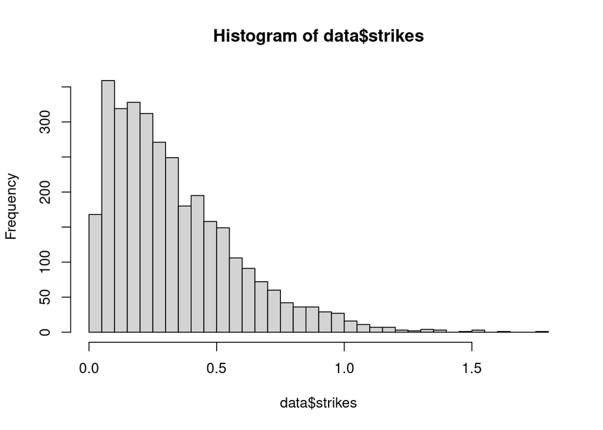

2. split data into training and testing
3. Standardize predictor variables

```
##         strikes        cape     precip        cxp         tair       wind
## 2463 0.78012023 -0.22013273 -0.9649462 -0.4996723  0.008682013  0.2917414
## 2511 0.60433580 -0.07401802 -0.5376400  0.3549663  0.016337347  0.4937888
## 2227 0.49031880  1.36527166 -0.9170826  1.3432564  0.908842797 -1.6832981
## 526  0.09206185 -0.44446449  0.6477250 -0.2062843 -1.109461745 -0.4886311
## 195  0.24297490 -1.30282307 -0.8696711 -0.5836476 -1.430988183  0.5942870
## 2986 0.54719295  1.31862775 -0.5596951  0.8908621  0.565856854 -0.4186747
##              swr          sp         rh
## 2463  1.88271376 -1.32660667 -1.3255755
## 2511  1.27187093  0.16712293 -0.7637808
## 2227  0.54060721 -0.05447395 -0.2020924
## 526  -0.69890161 -0.05741820  0.7304533
## 195  -0.00105241  0.39762071 -0.2987886
## 2986  0.50167529  0.43220243 -0.4681542
```

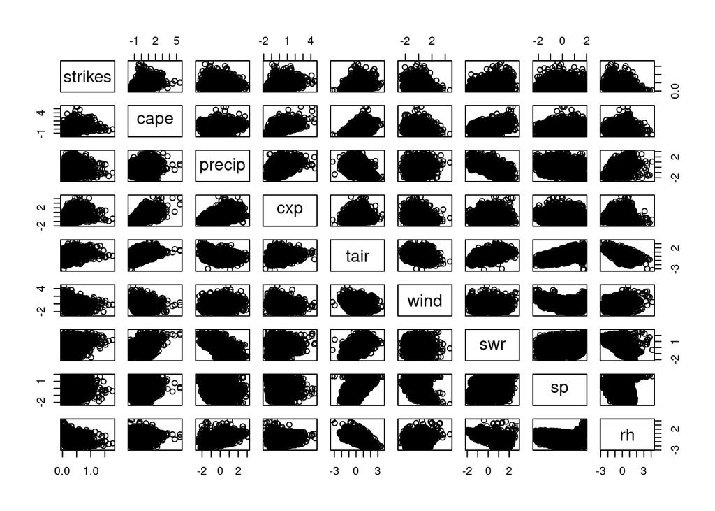

# M0: normal model, no dependance on climate

First, model lightning strike rate using the normal distribution with no dependence on climate. Other models will be compared with this model.

```
S ~ dnorm( mu , sigma ),
mu ~ dnorm(0,10),
sigma ~ dexp(0,10)
```

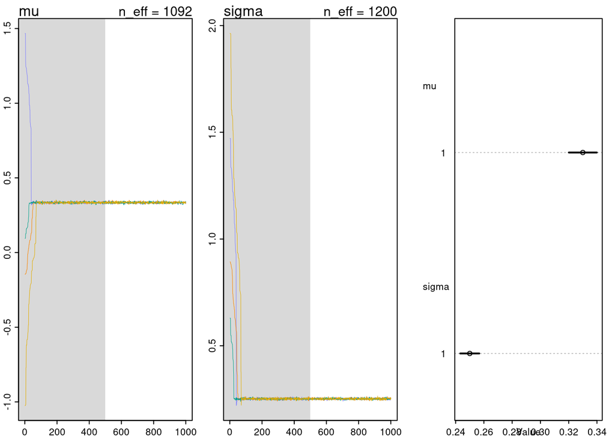

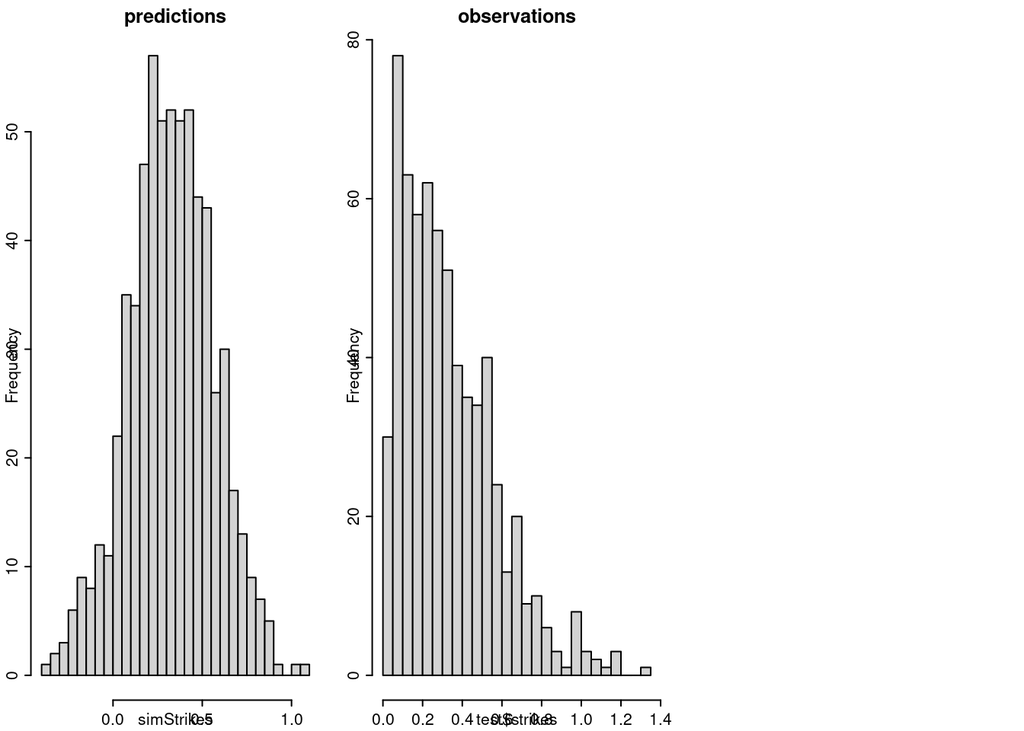

# M1: CAPE

Lightning strike rate modeled from a normal distribution where mu and sigma are dependant on climate: CAPE

```
S ~ dnorm( mu , sigma ),
mu <- a_mu + b_mu * CAPE,
sigma <- a_sigma + b_sigma * CAPE,
```

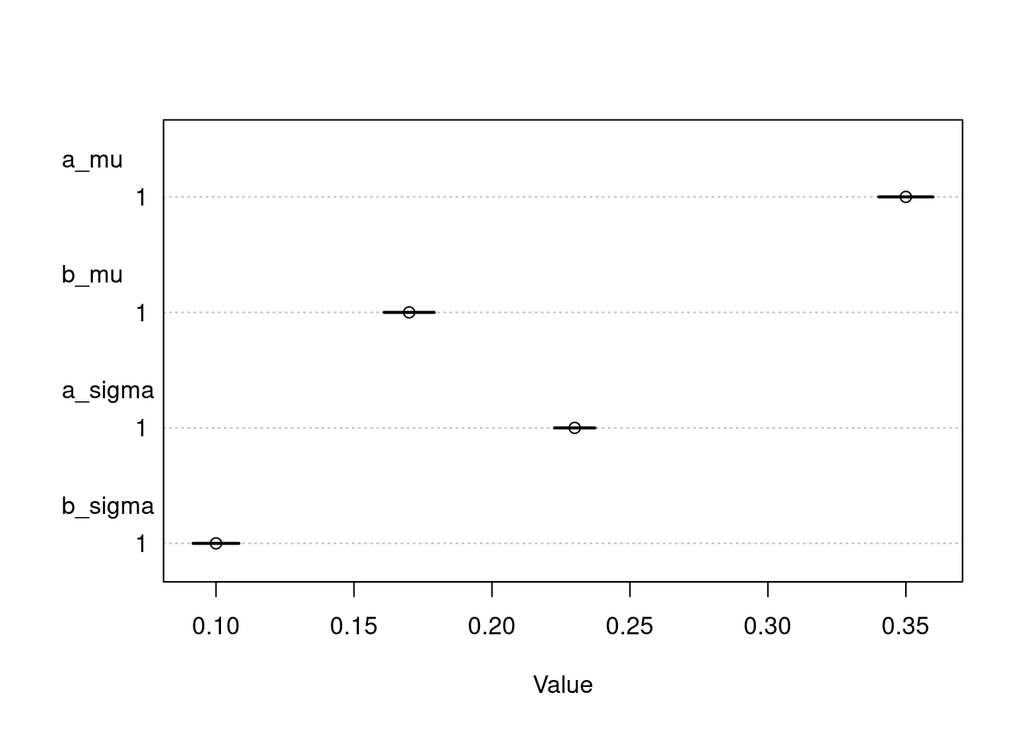

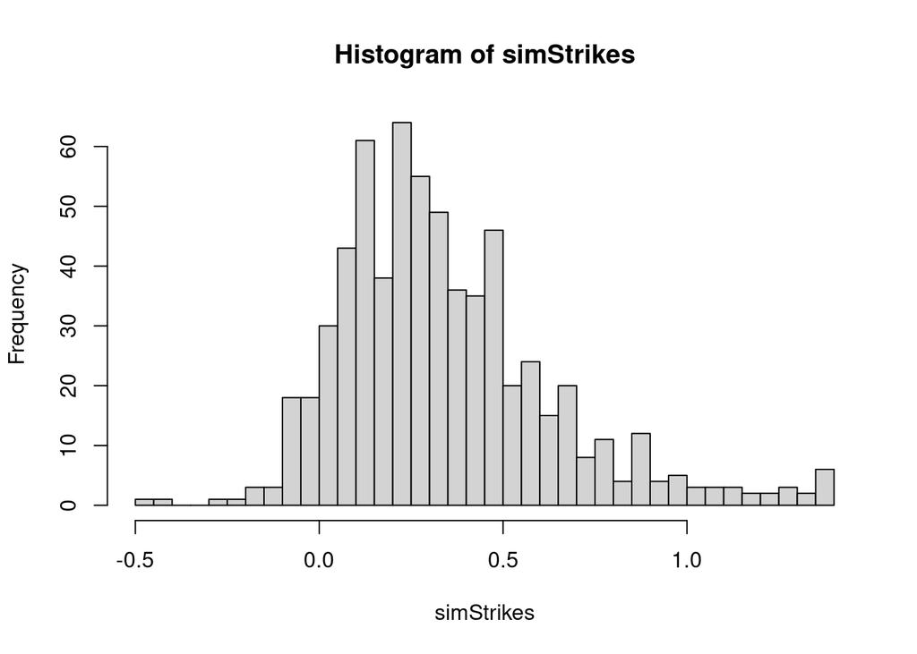

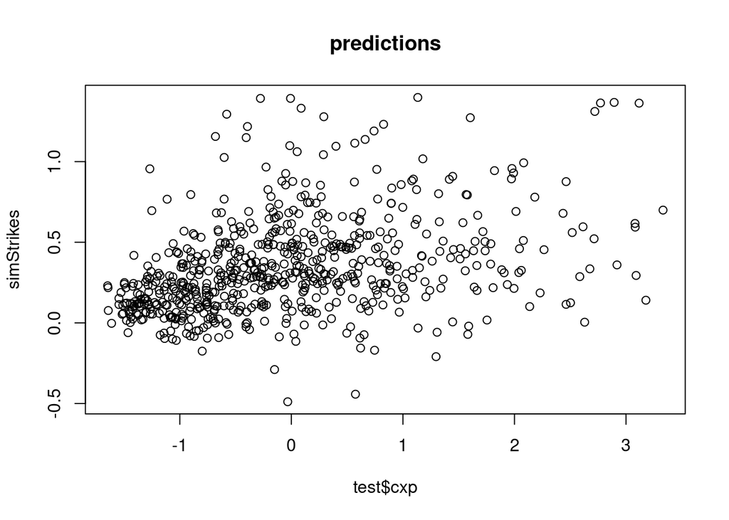

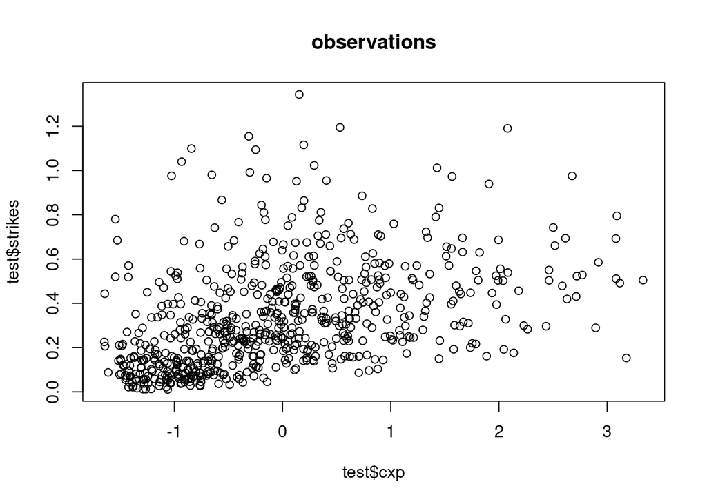

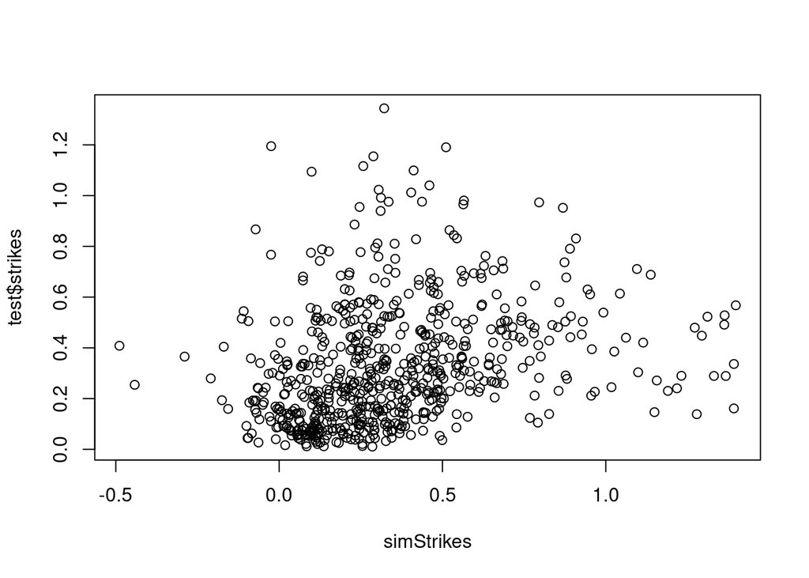

# M2: CAPE x Precipitation

Lighning strike rate modeled from a normal distribution where mu and sigma are dependant on climate: CAPE x Precipitation

```
S ~ dnorm( mu , sigma ),
mu <- a_mu + b_mu * CXP,
sigma <- a_sigma + b_sigma * CXP,
```

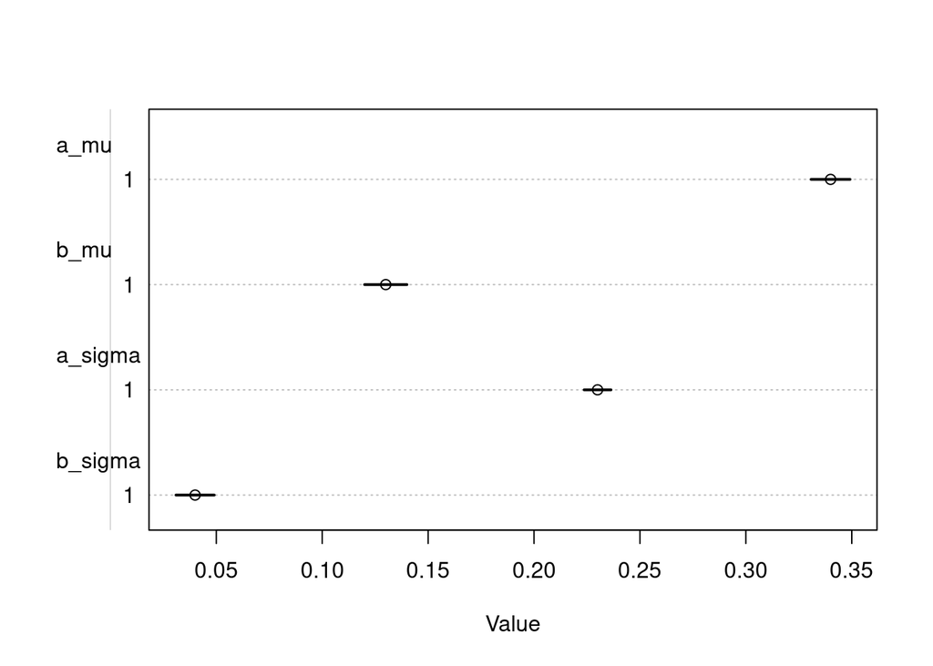

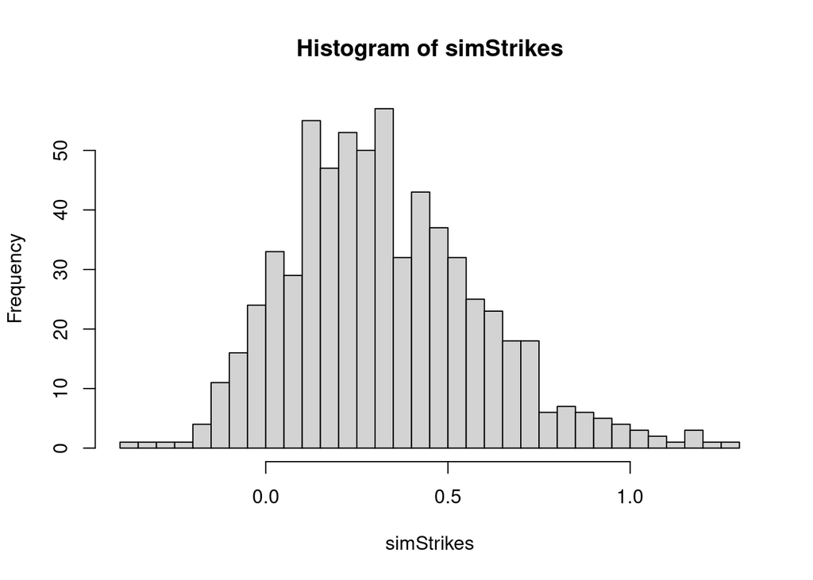

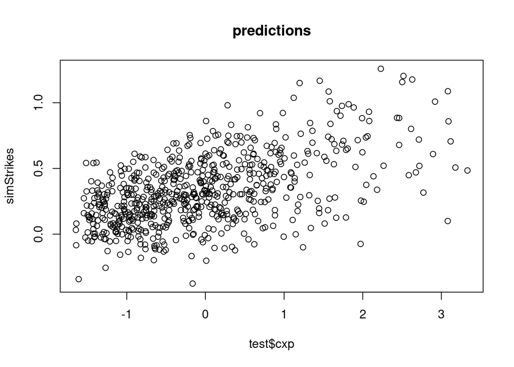

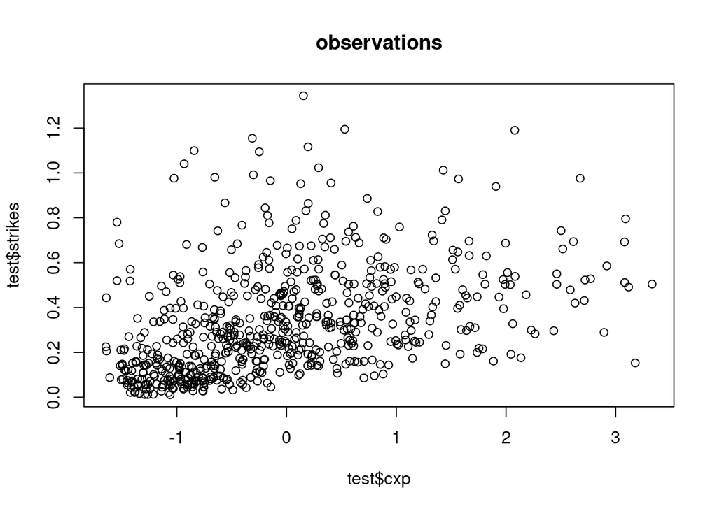

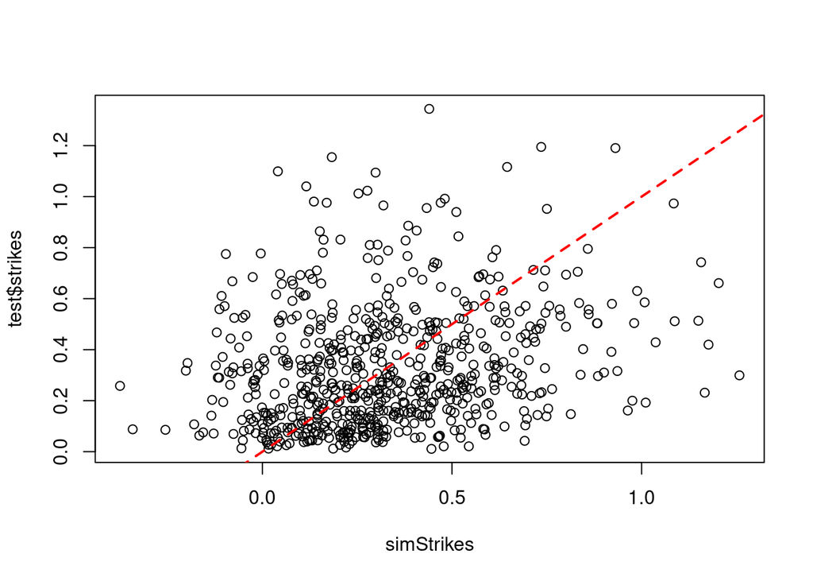

# M3: Relative Humidity

Lighning strike rate modeled from a normal distribution where mu and sigma are dependant on climate: Relative Humidity

```
S ~ dnorm( mu , sigma ),
mu <- a_mu + b_mu * RH,
sigma <- a_sigma + b_sigma * RH,
```

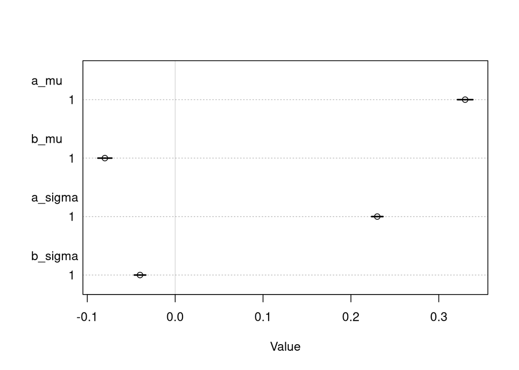

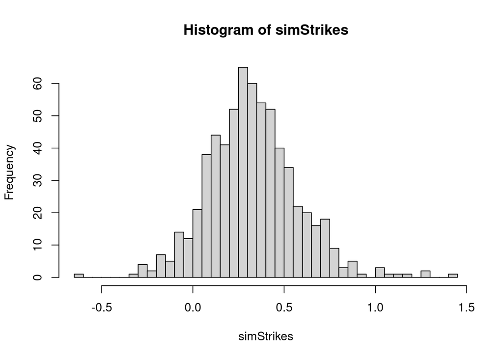

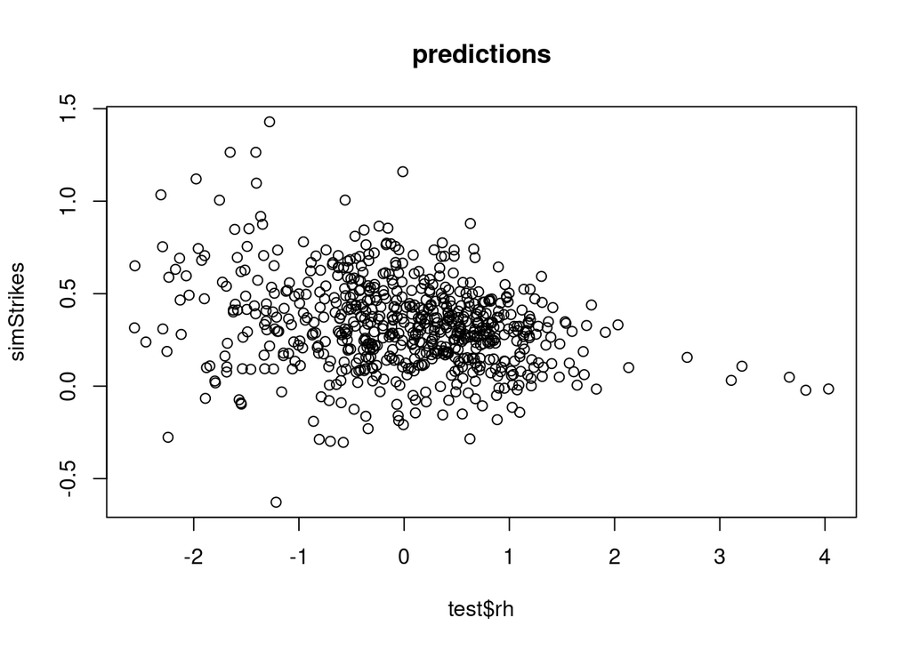

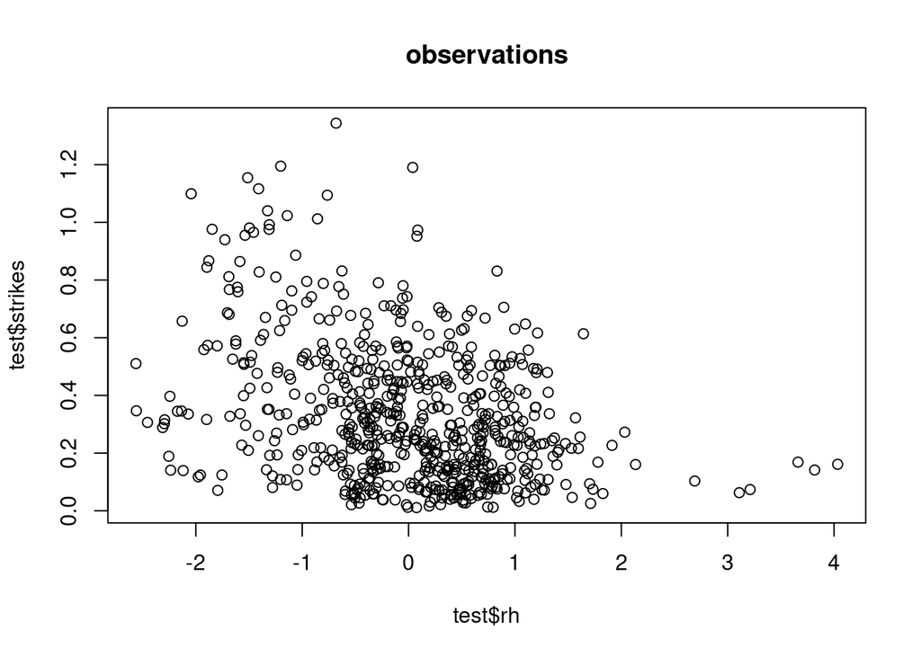

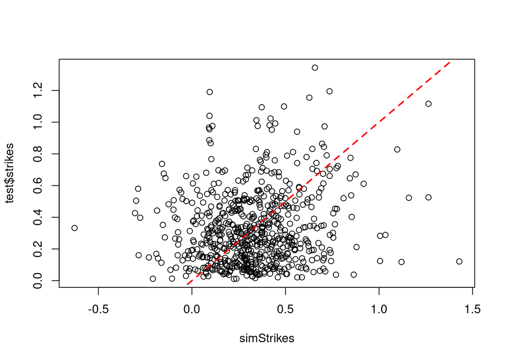

# M4: Short Wave Radiation

Lighning strike rate modeled from a normal distribution where mu and sigma are dependant on climate: Short wave radiation

```
S ~ dnorm( mu , sigma ),
mu <- a_mu + b_mu * SWR,
sigma <- a_sigma + b_sigma * SWR,
```

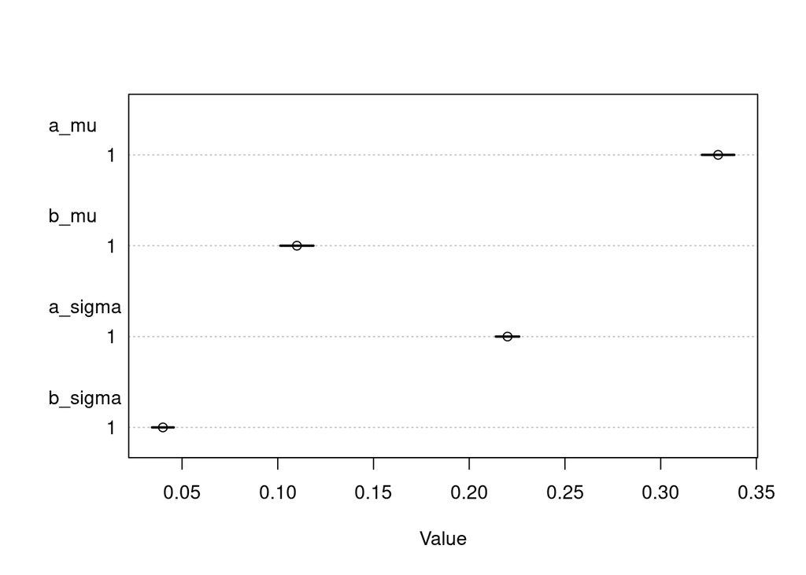

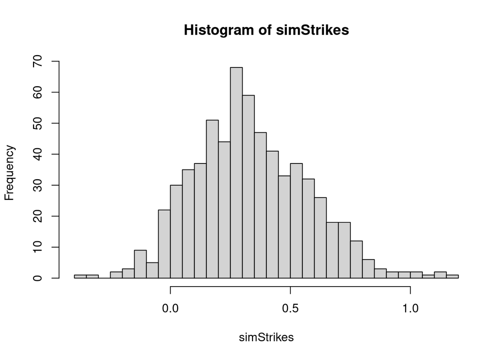

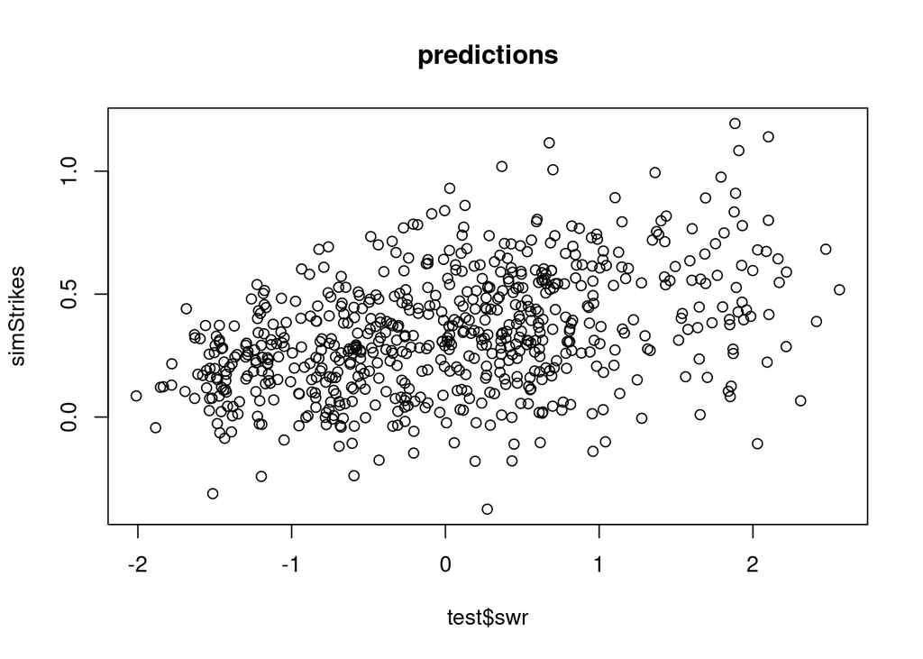

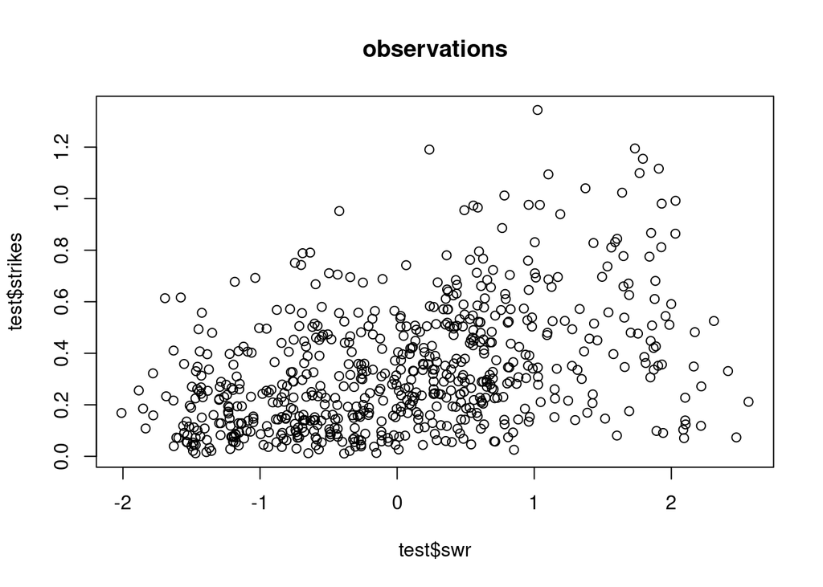

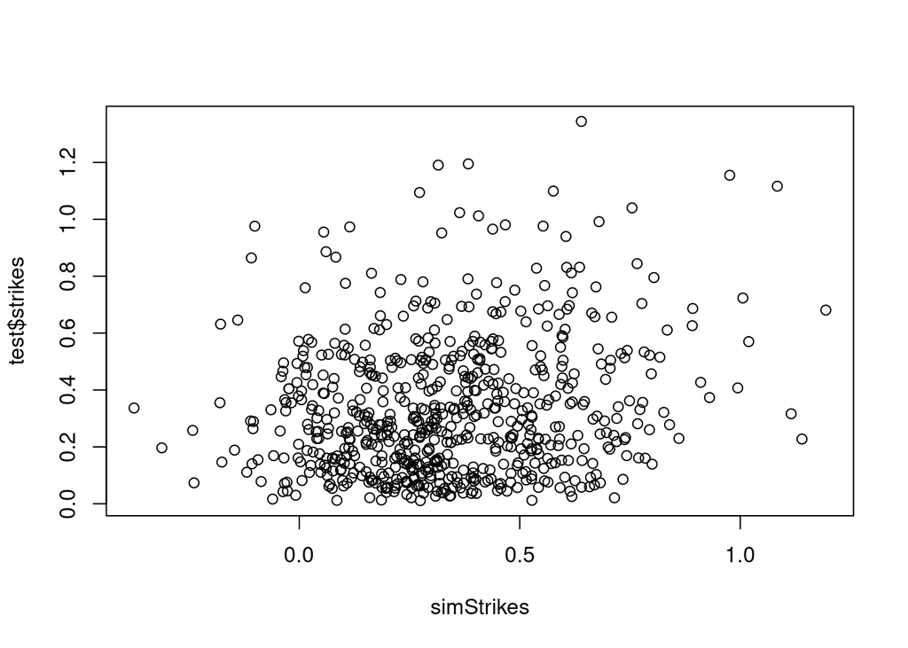

# M5: Temperature

Lightning strike rate modeled from a normal distribution where mu and sigma are dependant on climate: Temperature

```
S ~ dnorm( mu , sigma ),
mu <- a_mu + b_mu * T,
sigma <- a_sigma + b_sigma * T,
```

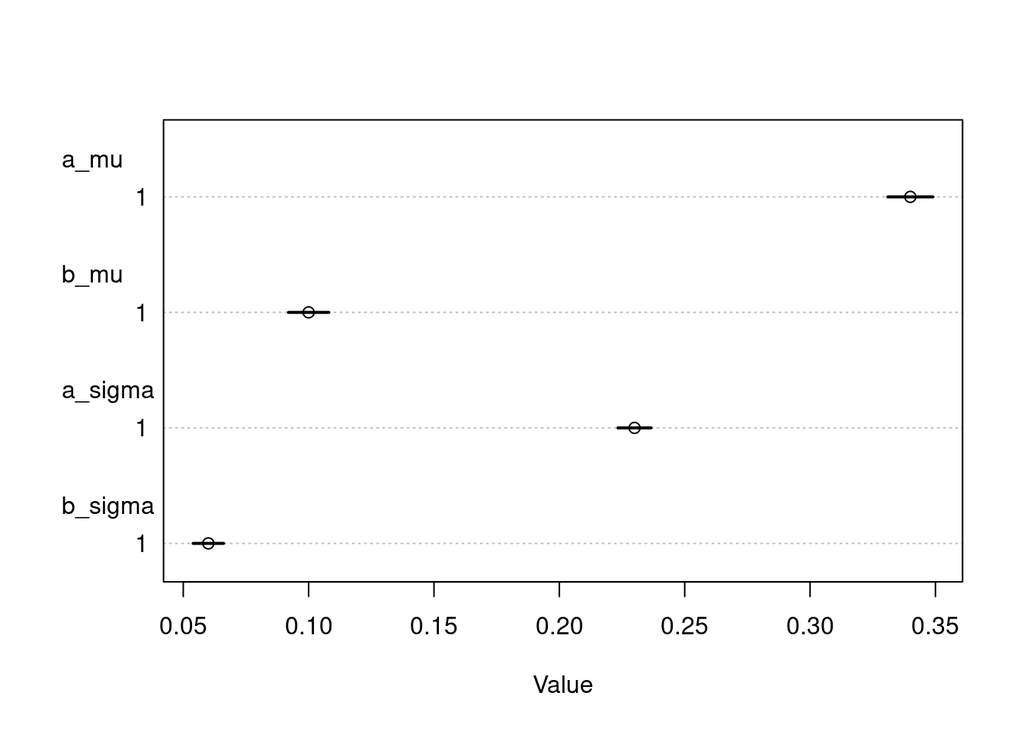

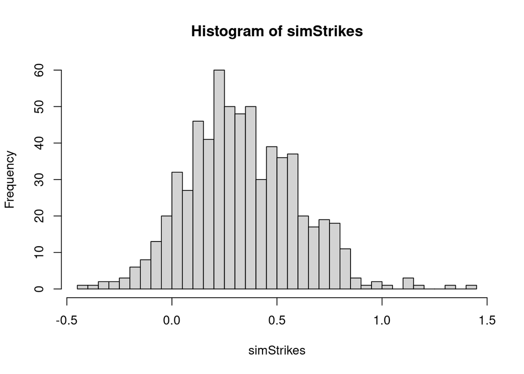

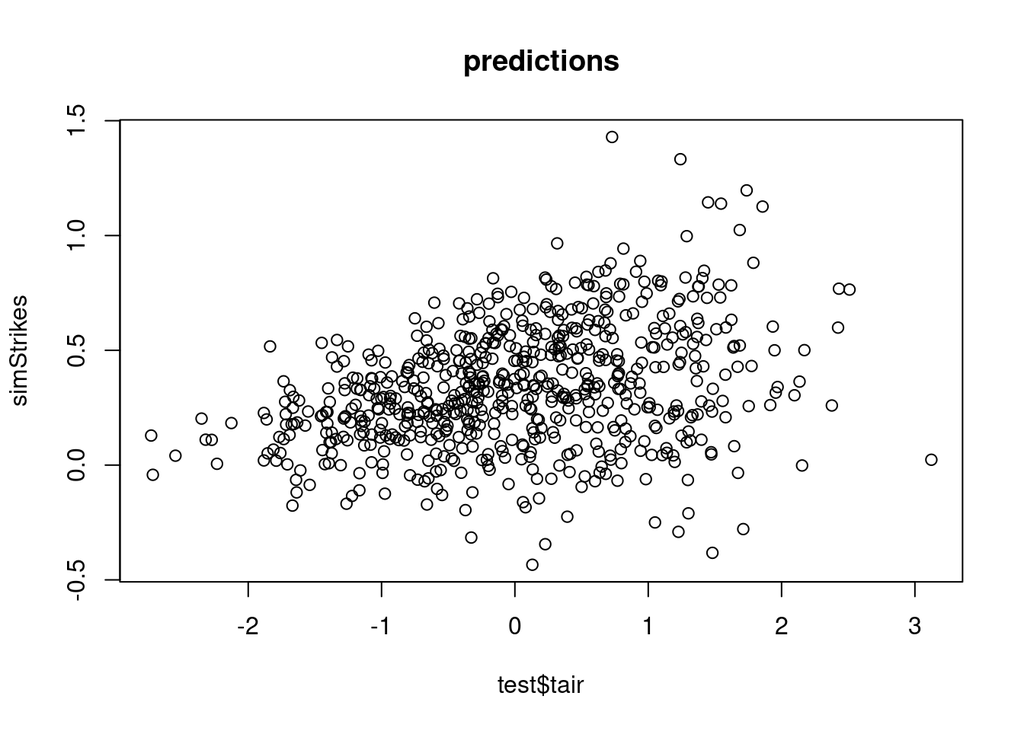

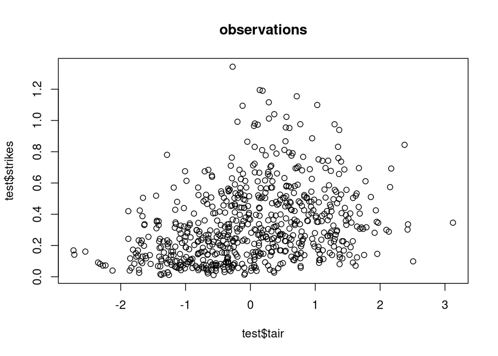

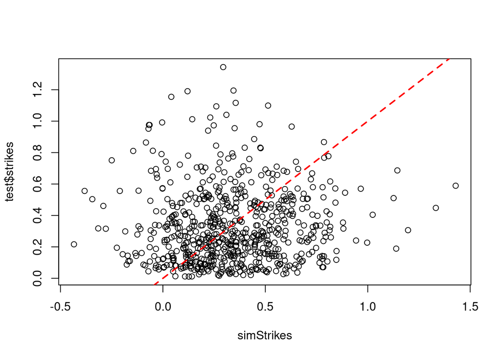